# TidyVerse Part 2

Priya Shaji

5/3/2019

## Tidyverse Assignment Part 2

Expansion of `Santosh Cheruku's Black friday sales dataset.`

Santosh Cheruku’s exloratory data analysis and code on Black Friday sales can be found on the following github link:

https://github.com/acatlin/SPRING2019TIDYVERSE/blob/master/Tidyverse_Mutate_functions.rmd

The dataset here is a sample of the transactions made in a retail store. The store wants to know better the customer purchase behaviour against different products. Specifically, here the problem is a regression problem where we are trying to predict the dependent variable (the amount of purchase) with the help of the information contained in the other variables.

Classification problem can also be settled in this dataset since several variables are categorical, and some other approaches could be “Predicting the age of the consumer” or even “Predict the category of goods bought”. This dataset is also particularly convenient for clustering and maybe find different clusters of consumers within it.

In this part 2 , I will focus on data clustering and grouping of the black friday sales by age and purchase of goods.

### Load Data

Fistly, we will load data and libraries

```r
library(tidyverse)
library(DT)
```

Load the dataset

```r
sales_df <- read.csv("https://raw.githubusercontent.com/san123i/CUNY/master/Semester1/607/Tidyverse_assignment_data/BlackFriday.csv")
head(sales_df)
```

```
##   User_ID Product_ID Gender   Age Purchase
## 1 1000001  P00069042      F  0-17     8370
## 2 1000001  P00248942      F  0-17    15200
## 3 1000001  P00087842      F  0-17     1422
## 4 1000001  P00085442      F  0-17     1057
## 5 1000002  P00285442      M   55+     7969
## 6 1000003  P00193542      M 26-35    15227
```

### Exploratory Data Analysis

Let’s see total purchasers on black friday

```r
# total purchaser
sales_df %>%
distinct(User_ID) %>%
nrow() %>%
paste("buyers registered at Black Friday")
```

```
## [1] "161 buyers registered at Black Friday"
```

### Groups and Distributions

#### Total Purchase Distribution

Here the distribution of goods will be analyzed based on purchase.

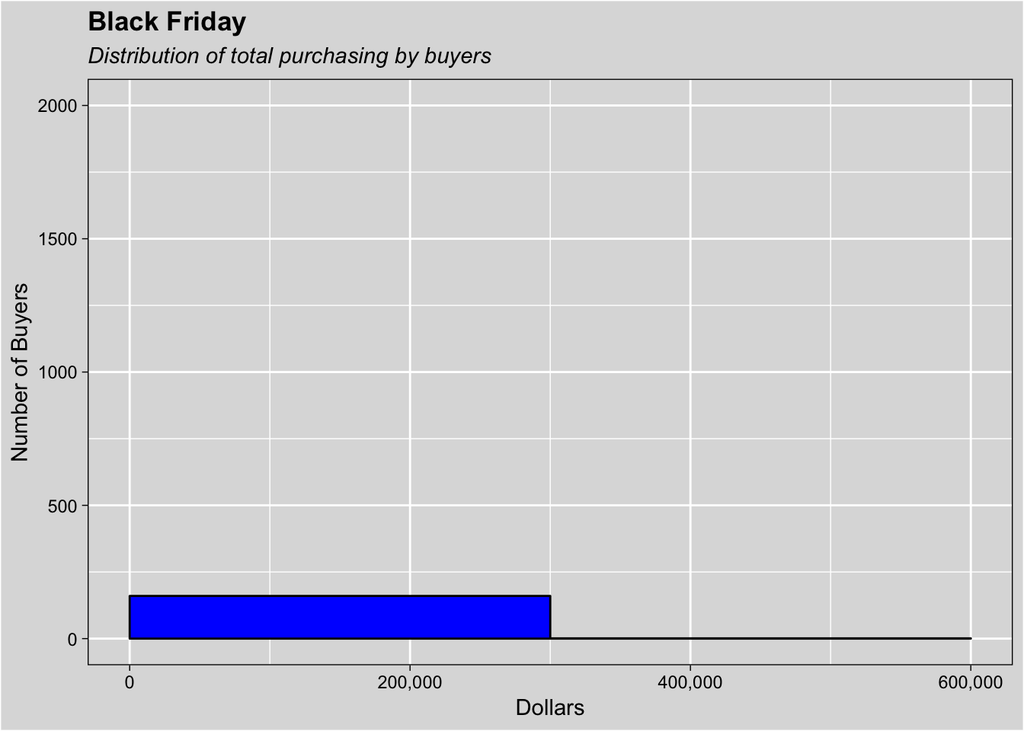

```r
#total purchase distribution
sales_df %>%
group_by(User_ID) %>%
summarise(total_purchase = sum(Purchase)) %>%
ggplot(aes(x = total_purchase)) +
geom_histogram(col = 'black', fill = 'blue', binwidth = 300000, center = 150000) +
theme_linedraw() +
theme(panel.background = element_rect(fill = "gainsboro", colour = "white", size = 0.5, linetype = "solid"), #theme panel settings
      plot.background = element_rect(fill = "gainsboro"), #theme panel settings
      panel.grid.major = element_line(size = 0.5, linetype = 'solid', colour = "white"), #theme panel settings
      panel.grid.minor = element_line(size = 0.25, linetype = 'solid', colour = "white"), #theme panel settings
      plot.title = element_text(hjust = 0, face = 'bold',color = 'black'), #title settings
      plot.subtitle = element_text(face = "italic")) + #subtitle settings
labs(x = 'Dollars', y = 'Number of Buyers', title = "Black Friday", #name title and axis
     subtitle = "Distribution of total purchasing by buyers") + #name subtitle
scale_y_continuous(limits = c(0,2000), breaks = c(0,500,1000,1500,2000)) + #set axis limits and break
scale_x_continuous(labels = scales::comma) #prevent scientific number in x-axis
```

#### Total Purchase by Product ID and Gender

Here the distribution of goods will be analyzed based on Product ID and Gender.

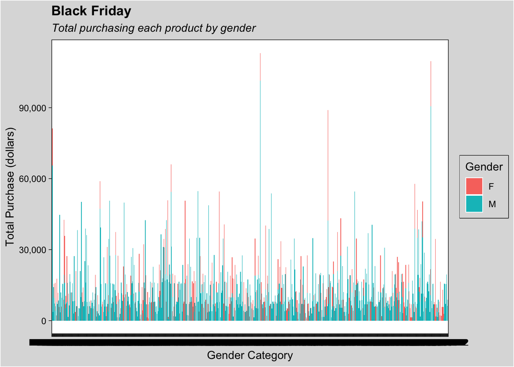

```r
#total purchase distribution grouping by City and Gender
sales_df %>%
group_by(Product_ID, Gender) %>%
summarise(total_purchase = sum(Purchase)) %>%
ggplot(aes(x=Product_ID, y = total_purchase)) +
geom_col(aes(fill = Gender)) +
theme_linedraw() +
theme(legend.box.background = element_rect(colour = "black"),
      legend.background = element_rect(fill = "gainsboro"),
      panel.background = element_rect(fill = "gainsboro", colour = "white", size = 0.5, linetype = "solid"), #theme panel settings
      plot.background = element_rect(fill = "gainsboro"), #theme panel settings
      panel.grid.major = element_line(size = 0.5, linetype = 'solid', colour = "white"), #theme panel settings
      panel.grid.minor = element_line(size = 0.25, linetype = 'solid', colour = "white"), #theme panel settings
      plot.title = element_text(hjust = 0, face = 'bold',color = 'black'), #title settings
      plot.subtitle = element_text(face = "italic")) + #subtitle settings
labs(x = 'Gender Category', y = 'Total Purchase (dollars)', title = "Black Friday", #name title and axis
     subtitle = "Total purchasing each product by gender") + #name subtitle
guides(fill=guide_legend(title = "Gender")) + #remove color legend
scale_y_continuous(labels = scales::comma) #prevent scientific number in x-axis
```

Here the distribution of goods will be analyzed based on Gender.

```r
#gender
gender <- sales_df %>%
          group_by(Gender) %>%
          distinct(User_ID) %>%
          summarise(Total=n())
gender
```

```
## # A tibble: 2 x 2
##   Gender Total
##   <fct>  <int>
## 1 F         49
## 2 M        112
```

Here the distribution of goods will be analyzed based on Age.

```r
#Age
age <- sales_df %>%
       group_by(Age) %>%
       summarise(Total=n())
age
```

```
## # A tibble: 7 x 2
##   Age   Total
##   <fct> <int>
## 1 0-17     42
## 2 18-25   214
## 3 26-35   342
## 4 36-45   200
## 5 46-50   121
## 6 51-55    54
## 7 55+      28
```

### Data Clustering

Clustering is a broad set of techniques for finding subgroups of observations within a data set. When we cluster observations, we want observations in the same group to be similar and observations in different groups to be dissimilar. Because there isn’t a response variable, this is an unsupervised method, which implies that it seeks to find relationships between the n observations without being trained by a response variable.

```r
BlackFridayForClustering <- sales_df %>%
                            select(Purchase)
```

#### Number of Cluster

Determine the Number of Cluster

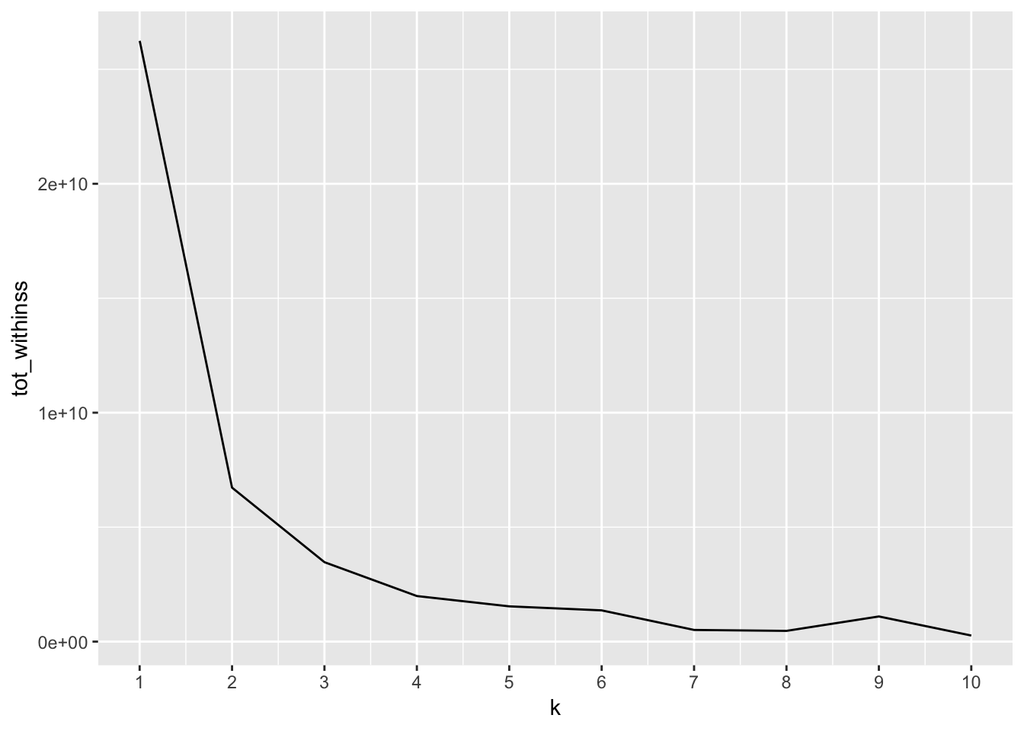

```r
# Use map_dbl to run many models with varying value of k (centers)
tot_withinss <- map_dbl(1:10,  function(k){
  model <- kmeans(x = BlackFridayForClustering, centers = k)
  model$tot.withinss
})

# Generate a data frame containing both k and tot_withinss
elbow_df <- data.frame(
  k = 1:10,
  tot_withinss = tot_withinss
)

# Plot the elbow plot
ggplot(elbow_df, aes(x = k, y = tot_withinss)) +
  geom_line() +
  scale_x_continuous(breaks = 1:10)
```

#### Cluster Model

```r
# Build a kmeans model
model_km3 <- kmeans(BlackFridayForClustering, centers = 3)

# Extract the cluster assignment vector from the kmeans model
clust_km3 <- model_km3$cluster

# Create a new dataframe appending the cluster assignment
BlackFriday_Clust <- mutate(sales_df, cluster = clust_km3)

# summarise the clustering
BlackFriday_Clust_Note <- BlackFriday_Clust %>%
                          group_by(cluster) %>%
                          summarise(min_purchase = min(Purchase),
                                   max_purchase = max(Purchase),
                                   avg_purchase = round(mean(Purchase),0))
```

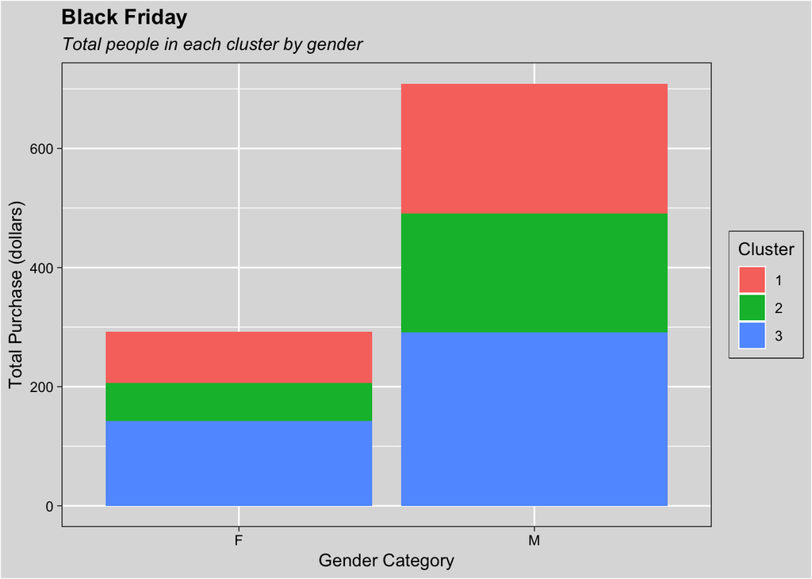

```r
# how many people in each cluster
BlackFriday_Clust %>%
group_by(Gender, cluster) %>%
summarise(n = n()) %>%
ggplot(aes(x=Gender, y = n)) +
geom_col(aes(fill = as.factor(cluster))) +
theme_linedraw() +
theme(legend.box.background = element_rect(colour = "black"),
      legend.background = element_rect(fill = "gainsboro"),
      panel.background = element_rect(fill = "gainsboro", colour = "white", size = 0.5, linetype = "solid"), #theme panel settings
      plot.background = element_rect(fill = "gainsboro"), #theme panel settings
      panel.grid.major = element_line(size = 0.5, linetype = 'solid', colour = "white"), #theme panel settings
      panel.grid.minor = element_line(size = 0.25, linetype = 'solid', colour = "white"), #theme panel settings
      plot.title = element_text(hjust = 0, face = 'bold',color = 'black'), #title settings
      plot.subtitle = element_text(face = "italic")) + #subtitle settings
labs(x = 'Gender Category', y = 'Total Purchase (dollars)', title = "Black Friday", #name title and axis
     subtitle = "Total people in each cluster by gender") + #name subtitle
guides(fill=guide_legend(title = "Cluster")) + #remove color legend
scale_y_continuous(labels = scales::comma) #prevent scientific number in x-axis
```

### Reference

1. https://uc-r.github.io/kmeans_clustering